# Risk Factor Analysis

## Outcome Variable

**Outcome Variable:** ever_wasted

## Predictor Variables

**Intervention Variable:** enstunt

**Adjustment Set:**

- arm
- sex
- W_mage
- meducyrs
- feducyrs
- vagbrth
- single
- brthmon
- W_parity
- delta_W_mage
- delta_meducyrs
- delta_feducyrs
- delta_vagbrth
- delta_single
- delta_brthmon
- delta_W_parity

## Stratifying Variables

The analysis was stratified on these variable(s):

- agecat
- studyid
- country

## Data Summary

| agecat | studyid | country | enstunt | ever_wasted | n_cell | n |
| --- | --- | --- | --- | --- | --- | --- |
| 0-24 months (no birth wast) | CMC-V-BCS-2002 | INDIA | 0 | 0 | 166 | 368 |
| 0-24 months (no birth wast) | CMC-V-BCS-2002 | INDIA | 0 | 1 | 127 | 368 |
| 0-24 months (no birth wast) | CMC-V-BCS-2002 | INDIA | 1 | 0 | 36 | 368 |
| 0-24 months (no birth wast) | CMC-V-BCS-2002 | INDIA | 1 | 1 | 39 | 368 |
| 0-24 months (no birth wast) | CMIN | BANGLADESH | 0 | 0 | 103 | 268 |
| 0-24 months (no birth wast) | CMIN | BANGLADESH | 0 | 1 | 63 | 268 |
| 0-24 months (no birth wast) | CMIN | BANGLADESH | 1 | 0 | 50 | 268 |
| 0-24 months (no birth wast) | CMIN | BANGLADESH | 1 | 1 | 52 | 268 |
| 0-24 months (no birth wast) | COHORTS | GUATEMALA | 0 | 0 | 910 | 1332 |
| 0-24 months (no birth wast) | COHORTS | GUATEMALA | 0 | 1 | 103 | 1332 |
| 0-24 months (no birth wast) | COHORTS | GUATEMALA | 1 | 0 | 263 | 1332 |
| 0-24 months (no birth wast) | COHORTS | GUATEMALA | 1 | 1 | 56 | 1332 |
| 0-24 months (no birth wast) | COHORTS | INDIA | 0 | 0 | 5189 | 7135 |
| 0-24 months (no birth wast) | COHORTS | INDIA | 0 | 1 | 1099 | 7135 |
| 0-24 months (no birth wast) | COHORTS | INDIA | 1 | 0 | 636 | 7135 |
| 0-24 months (no birth wast) | COHORTS | INDIA | 1 | 1 | 211 | 7135 |
| 0-24 months (no birth wast) | COHORTS | PHILIPPINES | 0 | 0 | 2004 | 3019 |
| 0-24 months (no birth wast) | COHORTS | PHILIPPINES | 0 | 1 | 841 | 3019 |
| 0-24 months (no birth wast) | COHORTS | PHILIPPINES | 1 | 0 | 99 | 3019 |
| 0-24 months (no birth wast) | COHORTS | PHILIPPINES | 1 | 1 | 75 | 3019 |
| 0-24 months (no birth wast) | CONTENT | PERU | 0 | 0 | 192 | 215 |
| 0-24 months (no birth wast) | CONTENT | PERU | 0 | 1 | 3 | 215 |
| 0-24 months (no birth wast) | CONTENT | PERU | 1 | 0 | 19 | 215 |
| 0-24 months (no birth wast) | CONTENT | PERU | 1 | 1 | 1 | 215 |
| 0-24 months (no birth wast) | EE | PAKISTAN | 0 | 0 | 111 | 377 |
| 0-24 months (no birth wast) | EE | PAKISTAN | 0 | 1 | 100 | 377 |
| 0-24 months (no birth wast) | EE | PAKISTAN | 1 | 0 | 63 | 377 |
| 0-24 months (no birth wast) | EE | PAKISTAN | 1 | 1 | 103 | 377 |
| 0-24 months (no birth wast) | GMS-Nepal | NEPAL | 0 | 0 | 275 | 660 |
| 0-24 months (no birth wast) | GMS-Nepal | NEPAL | 0 | 1 | 278 | 660 |

[output cut: 214 more lines]

The following strata were considered:

- agecat: 0-24 months (no birth wast), studyid: CMC-V-BCS-2002, country: INDIA
- agecat: 0-24 months (no birth wast), studyid: CMIN, country: BANGLADESH
- agecat: 0-24 months (no birth wast), studyid: COHORTS, country: GUATEMALA
- agecat: 0-24 months (no birth wast), studyid: COHORTS, country: INDIA
- agecat: 0-24 months (no birth wast), studyid: COHORTS, country: PHILIPPINES
- agecat: 0-24 months (no birth wast), studyid: CONTENT, country: PERU
- agecat: 0-24 months (no birth wast), studyid: EE, country: PAKISTAN
- agecat: 0-24 months (no birth wast), studyid: GMS-Nepal, country: NEPAL
- agecat: 0-24 months (no birth wast), studyid: Guatemala BSC, country: GUATEMALA
- agecat: 0-24 months (no birth wast), studyid: iLiNS-Zinc, country: BURKINA FASO
- agecat: 0-24 months (no birth wast), studyid: IRC, country: INDIA
- agecat: 0-24 months (no birth wast), studyid: JiVitA-3, country: BANGLADESH
- agecat: 0-24 months (no birth wast), studyid: JiVitA-4, country: BANGLADESH
- agecat: 0-24 months (no birth wast), studyid: Keneba, country: GAMBIA
- agecat: 0-24 months (no birth wast), studyid: LCNI-5, country: MALAWI
- agecat: 0-24 months (no birth wast), studyid: MAL-ED, country: BANGLADESH
- agecat: 0-24 months (no birth wast), studyid: MAL-ED, country: BRAZIL
- agecat: 0-24 months (no birth wast), studyid: MAL-ED, country: INDIA
- agecat: 0-24 months (no birth wast), studyid: MAL-ED, country: NEPAL
- agecat: 0-24 months (no birth wast), studyid: MAL-ED, country: PERU
- agecat: 0-24 months (no birth wast), studyid: MAL-ED, country: SOUTH AFRICA
- agecat: 0-24 months (no birth wast), studyid: MAL-ED, country: TANZANIA, UNITED REPUBLIC OF
- agecat: 0-24 months (no birth wast), studyid: NIH-Birth, country: BANGLADESH
- agecat: 0-24 months (no birth wast), studyid: NIH-Crypto, country: BANGLADESH
- agecat: 0-24 months (no birth wast), studyid: PROBIT, country: BELARUS
- agecat: 0-24 months (no birth wast), studyid: PROVIDE, country: BANGLADESH
- agecat: 0-24 months (no birth wast), studyid: ResPak, country: PAKISTAN
- agecat: 0-24 months (no birth wast), studyid: SAS-CompFeed, country: INDIA
- agecat: 0-24 months (no birth wast), studyid: SAS-FoodSuppl, country: INDIA
- agecat: 0-24 months (no birth wast), studyid: TanzaniaChild2, country: TANZANIA, UNITED REPUBLIC OF
- agecat: 0-24 months (no birth wast), studyid: ZVITAMBO, country: ZIMBABWE
- agecat: 0-6 months (no birth wast), studyid: CMC-V-BCS-2002, country: INDIA
- agecat: 0-6 months (no birth wast), studyid: CMIN, country: BANGLADESH
- agecat: 0-6 months (no birth wast), studyid: COHORTS, country: GUATEMALA
- agecat: 0-6 months (no birth wast), studyid: COHORTS, country: INDIA
- agecat: 0-6 months (no birth wast), studyid: COHORTS, country: PHILIPPINES
- agecat: 0-6 months (no birth wast), studyid: CONTENT, country: PERU
- agecat: 0-6 months (no birth wast), studyid: EE, country: PAKISTAN
- agecat: 0-6 months (no birth wast), studyid: GMS-Nepal, country: NEPAL
- agecat: 0-6 months (no birth wast), studyid: Guatemala BSC, country: GUATEMALA
- agecat: 0-6 months (no birth wast), studyid: IRC, country: INDIA
- agecat: 0-6 months (no birth wast), studyid: JiVitA-3, country: BANGLADESH
- agecat: 0-6 months (no birth wast), studyid: JiVitA-4, country: BANGLADESH
- agecat: 0-6 months (no birth wast), studyid: Keneba, country: GAMBIA
- agecat: 0-6 months (no birth wast), studyid: LCNI-5, country: MALAWI
- agecat: 0-6 months (no birth wast), studyid: MAL-ED, country: BANGLADESH
- agecat: 0-6 months (no birth wast), studyid: MAL-ED, country: BRAZIL
- agecat: 0-6 months (no birth wast), studyid: MAL-ED, country: INDIA
- agecat: 0-6 months (no birth wast), studyid: MAL-ED, country: NEPAL
- agecat: 0-6 months (no birth wast), studyid: MAL-ED, country: PERU
- agecat: 0-6 months (no birth wast), studyid: MAL-ED, country: SOUTH AFRICA
- agecat: 0-6 months (no birth wast), studyid: MAL-ED, country: TANZANIA, UNITED REPUBLIC OF
- agecat: 0-6 months (no birth wast), studyid: NIH-Birth, country: BANGLADESH
- agecat: 0-6 months (no birth wast), studyid: NIH-Crypto, country: BANGLADESH
- agecat: 0-6 months (no birth wast), studyid: PROBIT, country: BELARUS
- agecat: 0-6 months (no birth wast), studyid: PROVIDE, country: BANGLADESH
- agecat: 0-6 months (no birth wast), studyid: ResPak, country: PAKISTAN
- agecat: 0-6 months (no birth wast), studyid: SAS-CompFeed, country: INDIA
- agecat: 0-6 months (no birth wast), studyid: SAS-FoodSuppl, country: INDIA
- agecat: 0-6 months (no birth wast), studyid: TanzaniaChild2, country: TANZANIA, UNITED REPUBLIC OF
- agecat: 0-6 months (no birth wast), studyid: ZVITAMBO, country: ZIMBABWE

### Dropped Strata

Some strata were dropped due to rare outcomes:

- agecat: 0-24 months (no birth wast), studyid: CONTENT, country: PERU
- agecat: 0-24 months (no birth wast), studyid: MAL-ED, country: BRAZIL
- agecat: 0-6 months (no birth wast), studyid: COHORTS, country: GUATEMALA
- agecat: 0-6 months (no birth wast), studyid: CONTENT, country: PERU
- agecat: 0-6 months (no birth wast), studyid: Guatemala BSC, country: GUATEMALA
- agecat: 0-6 months (no birth wast), studyid: LCNI-5, country: MALAWI
- agecat: 0-6 months (no birth wast), studyid: MAL-ED, country: BRAZIL
- agecat: 0-6 months (no birth wast), studyid: MAL-ED, country: NEPAL
- agecat: 0-6 months (no birth wast), studyid: MAL-ED, country: PERU
- agecat: 0-6 months (no birth wast), studyid: MAL-ED, country: SOUTH AFRICA
- agecat: 0-6 months (no birth wast), studyid: MAL-ED, country: TANZANIA, UNITED REPUBLIC OF
- agecat: 0-6 months (no birth wast), studyid: NIH-Crypto, country: BANGLADESH
- agecat: 0-6 months (no birth wast), studyid: SAS-FoodSuppl, country: INDIA

## Methods Detail

We're interested in the causal parameters $E[Y_a]$ for all values of $a \in \mathcal{A}$. These parameters represent the mean outcome if, possibly contrary to fact, we intervened to set all units to have $A=a$. Under the randomization and positivity assumptions, these are identified by the statistical parameters $\psi_a=E_W[E_{Y|A,W}(Y|A=a,W)]$. In addition, we're interested in the mean of $Y$, $E[Y]$ under no intervention (the observed mean). We will estimate these parameters by using SuperLearner to fit the relevant likelihood factors -- $E_{Y|A,W}(Y|A=a,W)$ and $p(A=a|W)$, and then updating our likelihood fit using a joint TMLE.

For unadjusted analyses ($W=\{\}$), initial likelihoods were estimated using Lrnr_glm to estimate the simple $E(Y|A)$ and Lrnr_mean to estimate $p(A)$. For adjusted analyses, a small library containing Lrnr_glmnet, Lrnr_xgboost, and Lrnr_mean was used.

Having estimated these parameters, we will then use the delta method to estimate relative risks and attributable risks relative to a prespecified baseline level of $A$.

# Results Detail

## Results Plots

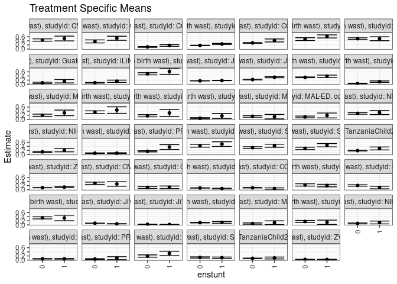

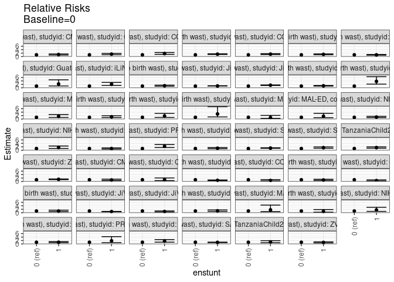

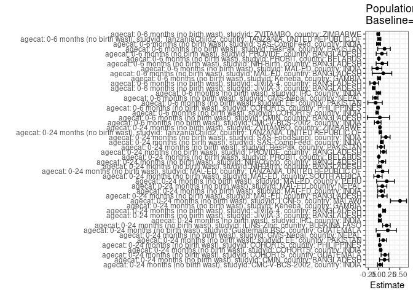

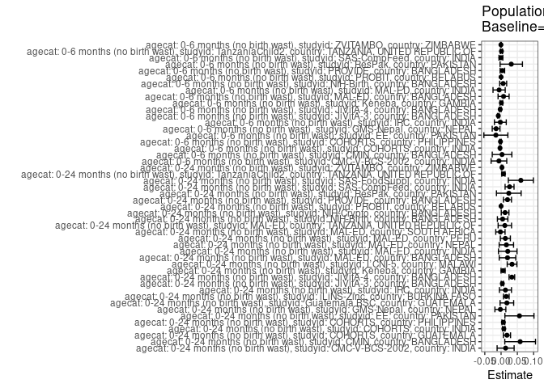

## Results Table

### Parameter: TSM

| agecat | studyid | country | intervention_level | baseline_level | estimate | ci_lower | ci_upper |
| --- | --- | --- | --- | --- | --- | --- | --- |
| 0-24 months (no birth wast) | CMC-V-BCS-2002 | INDIA | 0 | NA | 0.4371251 | 0.3801860 | 0.4940641 |
| 0-24 months (no birth wast) | CMC-V-BCS-2002 | INDIA | 1 | NA | 0.5120823 | 0.3965641 | 0.6276005 |
| 0-24 months (no birth wast) | CMIN | BANGLADESH | 0 | NA | 0.3704762 | 0.2970067 | 0.4439457 |
| 0-24 months (no birth wast) | CMIN | BANGLADESH | 1 | NA | 0.5242993 | 0.4251130 | 0.6234857 |
| 0-24 months (no birth wast) | COHORTS | GUATEMALA | 0 | NA | 0.1013818 | 0.0827744 | 0.1199892 |
| 0-24 months (no birth wast) | COHORTS | GUATEMALA | 1 | NA | 0.1764434 | 0.1340002 | 0.2188866 |
| 0-24 months (no birth wast) | COHORTS | INDIA | 0 | NA | 0.1751199 | 0.1657365 | 0.1845034 |
| 0-24 months (no birth wast) | COHORTS | INDIA | 1 | NA | 0.2450020 | 0.2158862 | 0.2741177 |
| 0-24 months (no birth wast) | COHORTS | PHILIPPINES | 0 | NA | 0.2963928 | 0.2796214 | 0.3131642 |
| 0-24 months (no birth wast) | COHORTS | PHILIPPINES | 1 | NA | 0.4169710 | 0.3445814 | 0.4893606 |
| 0-24 months (no birth wast) | EE | PAKISTAN | 0 | NA | 0.4820282 | 0.4139139 | 0.5501426 |
| 0-24 months (no birth wast) | EE | PAKISTAN | 1 | NA | 0.6132585 | 0.5395251 | 0.6869920 |
| 0-24 months (no birth wast) | GMS-Nepal | NEPAL | 0 | NA | 0.5036487 | 0.4619116 | 0.5453858 |
| 0-24 months (no birth wast) | GMS-Nepal | NEPAL | 1 | NA | 0.4996725 | 0.4048939 | 0.5944512 |
| 0-24 months (no birth wast) | Guatemala BSC | GUATEMALA | 0 | NA | 0.0652551 | 0.0344156 | 0.0960947 |
| 0-24 months (no birth wast) | Guatemala BSC | GUATEMALA | 1 | NA | 0.1449759 | 0.0627227 | 0.2272290 |
| 0-24 months (no birth wast) | iLiNS-Zinc | BURKINA FASO | 0 | NA | 0.0691275 | 0.0542319 | 0.0840231 |
| 0-24 months (no birth wast) | iLiNS-Zinc | BURKINA FASO | 1 | NA | 0.1427243 | 0.0867794 | 0.1986693 |
| 0-24 months (no birth wast) | IRC | INDIA | 0 | NA | 0.5073237 | 0.4553193 | 0.5593281 |
| 0-24 months (no birth wast) | IRC | INDIA | 1 | NA | 0.6175706 | 0.4793464 | 0.7557949 |
| 0-24 months (no birth wast) | JiVitA-3 | BANGLADESH | 0 | NA | 0.1655406 | 0.1592519 | 0.1718293 |
| 0-24 months (no birth wast) | JiVitA-3 | BANGLADESH | 1 | NA | 0.1803778 | 0.1709177 | 0.1898380 |
| 0-24 months (no birth wast) | JiVitA-4 | BANGLADESH | 0 | NA | 0.2246384 | 0.2092958 | 0.2399811 |
| 0-24 months (no birth wast) | JiVitA-4 | BANGLADESH | 1 | NA | 0.3387042 | 0.3120845 | 0.3653240 |
| 0-24 months (no birth wast) | Keneba | GAMBIA | 0 | NA | 0.3331079 | 0.3148234 | 0.3513924 |
| 0-24 months (no birth wast) | Keneba | GAMBIA | 1 | NA | 0.3870782 | 0.3322565 | 0.4419000 |
| 0-24 months (no birth wast) | LCNI-5 | MALAWI | 0 | NA | 0.0331460 | 0.0179738 | 0.0483182 |
| 0-24 months (no birth wast) | LCNI-5 | MALAWI | 1 | NA | 0.1234662 | 0.0863909 | 0.1605416 |
| 0-24 months (no birth wast) | MAL-ED | BANGLADESH | 0 | NA | 0.2008023 | 0.1474851 | 0.2541195 |
| 0-24 months (no birth wast) | MAL-ED | BANGLADESH | 1 | NA | 0.3168596 | 0.1813530 | 0.4523663 |

[output cut: 66 more lines]

### Parameter: E(Y)

| agecat | studyid | country | intervention_level | baseline_level | estimate | ci_lower | ci_upper |
| --- | --- | --- | --- | --- | --- | --- | --- |
| 0-24 months (no birth wast) | CMC-V-BCS-2002 | INDIA | NA | NA | 0.4510870 | 0.4001777 | 0.5019962 |
| 0-24 months (no birth wast) | CMIN | BANGLADESH | NA | NA | 0.4291045 | 0.3697365 | 0.4884725 |
| 0-24 months (no birth wast) | COHORTS | GUATEMALA | NA | NA | 0.1193694 | 0.1019512 | 0.1367875 |
| 0-24 months (no birth wast) | COHORTS | INDIA | NA | NA | 0.1836020 | 0.1746179 | 0.1925860 |
| 0-24 months (no birth wast) | COHORTS | PHILIPPINES | NA | NA | 0.3034117 | 0.2870099 | 0.3198136 |
| 0-24 months (no birth wast) | EE | PAKISTAN | NA | NA | 0.5384615 | 0.4880726 | 0.5888505 |
| 0-24 months (no birth wast) | GMS-Nepal | NEPAL | NA | NA | 0.5015152 | 0.4633406 | 0.5396897 |
| 0-24 months (no birth wast) | Guatemala BSC | GUATEMALA | NA | NA | 0.0830671 | 0.0524436 | 0.1136905 |
| 0-24 months (no birth wast) | iLiNS-Zinc | BURKINA FASO | NA | NA | 0.0850857 | 0.0676201 | 0.1025513 |
| 0-24 months (no birth wast) | IRC | INDIA | NA | NA | 0.5207824 | 0.4723080 | 0.5692568 |
| 0-24 months (no birth wast) | JiVitA-3 | BANGLADESH | NA | NA | 0.1693995 | 0.1641138 | 0.1746853 |
| 0-24 months (no birth wast) | JiVitA-4 | BANGLADESH | NA | NA | 0.2577835 | 0.2441424 | 0.2714247 |
| 0-24 months (no birth wast) | Keneba | GAMBIA | NA | NA | 0.3392608 | 0.3219301 | 0.3565915 |
| 0-24 months (no birth wast) | LCNI-5 | MALAWI | NA | NA | 0.0669056 | 0.0499685 | 0.0838427 |
| 0-24 months (no birth wast) | MAL-ED | BANGLADESH | NA | NA | 0.2205323 | 0.1703290 | 0.2707357 |
| 0-24 months (no birth wast) | MAL-ED | INDIA | NA | NA | 0.3699187 | 0.3094659 | 0.4303715 |
| 0-24 months (no birth wast) | MAL-ED | NEPAL | NA | NA | 0.1924686 | 0.1423823 | 0.2425550 |
| 0-24 months (no birth wast) | MAL-ED | PERU | NA | NA | 0.0695364 | 0.0408008 | 0.0982721 |
| 0-24 months (no birth wast) | MAL-ED | SOUTH AFRICA | NA | NA | 0.1461039 | 0.1065934 | 0.1856144 |
| 0-24 months (no birth wast) | MAL-ED | TANZANIA, UNITED REPUBLIC OF | NA | NA | 0.1302682 | 0.0893541 | 0.1711823 |
| 0-24 months (no birth wast) | NIH-Birth | BANGLADESH | NA | NA | 0.2956811 | 0.2591967 | 0.3321655 |
| 0-24 months (no birth wast) | NIH-Crypto | BANGLADESH | NA | NA | 0.1432361 | 0.1182149 | 0.1682572 |
| 0-24 months (no birth wast) | PROBIT | BELARUS | NA | NA | 0.0680135 | 0.0562135 | 0.0798135 |
| 0-24 months (no birth wast) | PROVIDE | BANGLADESH | NA | NA | 0.1775837 | 0.1489858 | 0.2061816 |
| 0-24 months (no birth wast) | ResPak | PAKISTAN | NA | NA | 0.4535714 | 0.3951549 | 0.5119879 |
| 0-24 months (no birth wast) | SAS-CompFeed | INDIA | NA | NA | 0.3615180 | 0.3107193 | 0.4123167 |
| 0-24 months (no birth wast) | SAS-FoodSuppl | INDIA | NA | NA | 0.3602015 | 0.3129196 | 0.4074834 |
| 0-24 months (no birth wast) | TanzaniaChild2 | TANZANIA, UNITED REPUBLIC OF | NA | NA | 0.1988255 | 0.1828010 | 0.2148500 |
| 0-24 months (no birth wast) | ZVITAMBO | ZIMBABWE | NA | NA | 0.1020019 | 0.0969221 | 0.1070817 |
| 0-6 months (no birth wast) | CMC-V-BCS-2002 | INDIA | NA | NA | 0.3085714 | 0.2601110 | 0.3570318 |
| 0-6 months (no birth wast) | CMIN | BANGLADESH | NA | NA | 0.1161049 | 0.0776073 | 0.1546024 |
| 0-6 months (no birth wast) | COHORTS | INDIA | NA | NA | 0.0820277 | 0.0753613 | 0.0886940 |
| 0-6 months (no birth wast) | COHORTS | PHILIPPINES | NA | NA | 0.0947298 | 0.0842456 | 0.1052141 |
| 0-6 months (no birth wast) | EE | PAKISTAN | NA | NA | 0.2160000 | 0.1742941 | 0.2577059 |
| 0-6 months (no birth wast) | GMS-Nepal | NEPAL | NA | NA | 0.1915888 | 0.1611224 | 0.2220551 |
| 0-6 months (no birth wast) | IRC | INDIA | NA | NA | 0.3410256 | 0.2939169 | 0.3881343 |
| 0-6 months (no birth wast) | JiVitA-3 | BANGLADESH | NA | NA | 0.0717008 | 0.0680635 | 0.0753382 |
| 0-6 months (no birth wast) | JiVitA-4 | BANGLADESH | NA | NA | 0.0256203 | 0.0209093 | 0.0303314 |
| 0-6 months (no birth wast) | Keneba | GAMBIA | NA | NA | 0.1117987 | 0.0992515 | 0.1243458 |
| 0-6 months (no birth wast) | MAL-ED | BANGLADESH | NA | NA | 0.0725191 | 0.0410556 | 0.1039825 |
| 0-6 months (no birth wast) | MAL-ED | INDIA | NA | NA | 0.1598361 | 0.1137612 | 0.2059110 |
| 0-6 months (no birth wast) | NIH-Birth | BANGLADESH | NA | NA | 0.0787671 | 0.0569010 | 0.1006332 |
| 0-6 months (no birth wast) | PROBIT | BELARUS | NA | NA | 0.0612233 | 0.0502388 | 0.0722078 |
| 0-6 months (no birth wast) | PROVIDE | BANGLADESH | NA | NA | 0.0541728 | 0.0371844 | 0.0711612 |
| 0-6 months (no birth wast) | ResPak | PAKISTAN | NA | NA | 0.2282609 | 0.1786550 | 0.2778667 |
| 0-6 months (no birth wast) | SAS-CompFeed | INDIA | NA | NA | 0.1255940 | 0.0954030 | 0.1557851 |
| 0-6 months (no birth wast) | TanzaniaChild2 | TANZANIA, UNITED REPUBLIC OF | NA | NA | 0.0858586 | 0.0745914 | 0.0971258 |
| 0-6 months (no birth wast) | ZVITAMBO | ZIMBABWE | NA | NA | 0.0319976 | 0.0290150 | 0.0349802 |

### Parameter: RR

| agecat | studyid | country | intervention_level | baseline_level | estimate | ci_lower | ci_upper |
| --- | --- | --- | --- | --- | --- | --- | --- |
| 0-24 months (no birth wast) | CMC-V-BCS-2002 | INDIA | 0 | 0 | 1.0000000 | 1.0000000 | 1.0000000 |
| 0-24 months (no birth wast) | CMC-V-BCS-2002 | INDIA | 1 | 0 | 1.1714778 | 0.9024476 | 1.5207091 |
| 0-24 months (no birth wast) | CMIN | BANGLADESH | 0 | 0 | 1.0000000 | 1.0000000 | 1.0000000 |
| 0-24 months (no birth wast) | CMIN | BANGLADESH | 1 | 0 | 1.4152039 | 1.0755077 | 1.8621923 |
| 0-24 months (no birth wast) | COHORTS | GUATEMALA | 0 | 0 | 1.0000000 | 1.0000000 | 1.0000000 |
| 0-24 months (no birth wast) | COHORTS | GUATEMALA | 1 | 0 | 1.7403852 | 1.2859459 | 2.3554184 |
| 0-24 months (no birth wast) | COHORTS | INDIA | 0 | 0 | 1.0000000 | 1.0000000 | 1.0000000 |
| 0-24 months (no birth wast) | COHORTS | INDIA | 1 | 0 | 1.3990522 | 1.2282124 | 1.5936553 |
| 0-24 months (no birth wast) | COHORTS | PHILIPPINES | 0 | 0 | 1.0000000 | 1.0000000 | 1.0000000 |
| 0-24 months (no birth wast) | COHORTS | PHILIPPINES | 1 | 0 | 1.4068189 | 1.1725443 | 1.6879016 |
| 0-24 months (no birth wast) | EE | PAKISTAN | 0 | 0 | 1.0000000 | 1.0000000 | 1.0000000 |
| 0-24 months (no birth wast) | EE | PAKISTAN | 1 | 0 | 1.2722461 | 1.0571042 | 1.5311736 |
| 0-24 months (no birth wast) | GMS-Nepal | NEPAL | 0 | 0 | 1.0000000 | 1.0000000 | 1.0000000 |
| 0-24 months (no birth wast) | GMS-Nepal | NEPAL | 1 | 0 | 0.9921052 | 0.8068083 | 1.2199586 |
| 0-24 months (no birth wast) | Guatemala BSC | GUATEMALA | 0 | 0 | 1.0000000 | 1.0000000 | 1.0000000 |
| 0-24 months (no birth wast) | Guatemala BSC | GUATEMALA | 1 | 0 | 2.2216778 | 1.0630455 | 4.6431242 |
| 0-24 months (no birth wast) | iLiNS-Zinc | BURKINA FASO | 0 | 0 | 1.0000000 | 1.0000000 | 1.0000000 |
| 0-24 months (no birth wast) | iLiNS-Zinc | BURKINA FASO | 1 | 0 | 2.0646538 | 1.3679183 | 3.1162643 |
| 0-24 months (no birth wast) | IRC | INDIA | 0 | 0 | 1.0000000 | 1.0000000 | 1.0000000 |
| 0-24 months (no birth wast) | IRC | INDIA | 1 | 0 | 1.2173107 | 0.9514562 | 1.5574499 |
| 0-24 months (no birth wast) | JiVitA-3 | BANGLADESH | 0 | 0 | 1.0000000 | 1.0000000 | 1.0000000 |
| 0-24 months (no birth wast) | JiVitA-3 | BANGLADESH | 1 | 0 | 1.0896289 | 1.0228499 | 1.1607678 |
| 0-24 months (no birth wast) | JiVitA-4 | BANGLADESH | 0 | 0 | 1.0000000 | 1.0000000 | 1.0000000 |
| 0-24 months (no birth wast) | JiVitA-4 | BANGLADESH | 1 | 0 | 1.5077751 | 1.3626026 | 1.6684144 |
| 0-24 months (no birth wast) | Keneba | GAMBIA | 0 | 0 | 1.0000000 | 1.0000000 | 1.0000000 |
| 0-24 months (no birth wast) | Keneba | GAMBIA | 1 | 0 | 1.1620205 | 0.9983949 | 1.3524625 |
| 0-24 months (no birth wast) | LCNI-5 | MALAWI | 0 | 0 | 1.0000000 | 1.0000000 | 1.0000000 |
| 0-24 months (no birth wast) | LCNI-5 | MALAWI | 1 | 0 | 3.7249174 | 2.1520334 | 6.4473953 |
| 0-24 months (no birth wast) | MAL-ED | BANGLADESH | 0 | 0 | 1.0000000 | 1.0000000 | 1.0000000 |
| 0-24 months (no birth wast) | MAL-ED | BANGLADESH | 1 | 0 | 1.5779680 | 0.9593465 | 2.5954991 |

[output cut: 66 more lines]

### Parameter: PAR

| agecat | studyid | country | intervention_level | baseline_level | estimate | ci_lower | ci_upper |
| --- | --- | --- | --- | --- | --- | --- | --- |
| 0-24 months (no birth wast) | CMC-V-BCS-2002 | INDIA | 0 | NA | 0.0139619 | -0.0121977 | 0.0401215 |
| 0-24 months (no birth wast) | CMIN | BANGLADESH | 0 | NA | 0.0586283 | 0.0114453 | 0.1058113 |
| 0-24 months (no birth wast) | COHORTS | GUATEMALA | 0 | NA | 0.0179876 | 0.0068761 | 0.0290990 |
| 0-24 months (no birth wast) | COHORTS | INDIA | 0 | NA | 0.0084820 | 0.0048093 | 0.0121548 |
| 0-24 months (no birth wast) | COHORTS | PHILIPPINES | 0 | NA | 0.0070189 | 0.0026476 | 0.0113903 |
| 0-24 months (no birth wast) | EE | PAKISTAN | 0 | NA | 0.0564333 | 0.0117622 | 0.1011044 |
| 0-24 months (no birth wast) | GMS-Nepal | NEPAL | 0 | NA | -0.0021336 | -0.0189423 | 0.0146751 |
| 0-24 months (no birth wast) | Guatemala BSC | GUATEMALA | 0 | NA | 0.0178120 | -0.0030822 | 0.0387062 |
| 0-24 months (no birth wast) | iLiNS-Zinc | BURKINA FASO | 0 | NA | 0.0159582 | 0.0071341 | 0.0247824 |
| 0-24 months (no birth wast) | IRC | INDIA | 0 | NA | 0.0134587 | -0.0050312 | 0.0319485 |
| 0-24 months (no birth wast) | JiVitA-3 | BANGLADESH | 0 | NA | 0.0038589 | 0.0003610 | 0.0073568 |
| 0-24 months (no birth wast) | JiVitA-4 | BANGLADESH | 0 | NA | 0.0331451 | 0.0244859 | 0.0418043 |
| 0-24 months (no birth wast) | Keneba | GAMBIA | 0 | NA | 0.0061529 | -0.0001612 | 0.0124670 |
| 0-24 months (no birth wast) | LCNI-5 | MALAWI | 0 | NA | 0.0337596 | 0.0188432 | 0.0486759 |
| 0-24 months (no birth wast) | MAL-ED | BANGLADESH | 0 | NA | 0.0197300 | -0.0057127 | 0.0451727 |
| 0-24 months (no birth wast) | MAL-ED | INDIA | 0 | NA | 0.0204843 | -0.0079963 | 0.0489648 |
| 0-24 months (no birth wast) | MAL-ED | NEPAL | 0 | NA | 0.0162781 | -0.0058443 | 0.0384006 |
| 0-24 months (no birth wast) | MAL-ED | PERU | 0 | NA | 0.0131454 | -0.0022995 | 0.0285904 |
| 0-24 months (no birth wast) | MAL-ED | SOUTH AFRICA | 0 | NA | -0.0020443 | -0.0163339 | 0.0122454 |
| 0-24 months (no birth wast) | MAL-ED | TANZANIA, UNITED REPUBLIC OF | 0 | NA | 0.0115467 | -0.0090588 | 0.0321522 |
| 0-24 months (no birth wast) | NIH-Birth | BANGLADESH | 0 | NA | 0.0047997 | -0.0112659 | 0.0208654 |
| 0-24 months (no birth wast) | NIH-Crypto | BANGLADESH | 0 | NA | 0.0123264 | 0.0005519 | 0.0241008 |
| 0-24 months (no birth wast) | PROBIT | BELARUS | 0 | NA | 0.0000013 | -0.0005524 | 0.0005550 |
| 0-24 months (no birth wast) | PROVIDE | BANGLADESH | 0 | NA | 0.0196533 | 0.0073288 | 0.0319778 |
| 0-24 months (no birth wast) | ResPak | PAKISTAN | 0 | NA | 0.0237421 | -0.0142070 | 0.0616913 |
| 0-24 months (no birth wast) | SAS-CompFeed | INDIA | 0 | NA | 0.0260710 | 0.0123371 | 0.0398049 |
| 0-24 months (no birth wast) | SAS-FoodSuppl | INDIA | 0 | NA | 0.0608093 | 0.0223093 | 0.0993093 |
| 0-24 months (no birth wast) | TanzaniaChild2 | TANZANIA, UNITED REPUBLIC OF | 0 | NA | 0.0072513 | 0.0022201 | 0.0122825 |
| 0-24 months (no birth wast) | ZVITAMBO | ZIMBABWE | 0 | NA | 0.0028048 | 0.0009068 | 0.0047027 |
| 0-6 months (no birth wast) | CMC-V-BCS-2002 | INDIA | 0 | NA | -0.0065825 | -0.0306645 | 0.0174995 |
| 0-6 months (no birth wast) | CMIN | BANGLADESH | 0 | NA | 0.0030112 | -0.0271272 | 0.0331496 |
| 0-6 months (no birth wast) | COHORTS | INDIA | 0 | NA | -0.0032695 | -0.0053055 | -0.0012335 |
| 0-6 months (no birth wast) | COHORTS | PHILIPPINES | 0 | NA | -0.0018369 | -0.0040611 | 0.0003873 |
| 0-6 months (no birth wast) | EE | PAKISTAN | 0 | NA | -0.0160081 | -0.0528668 | 0.0208506 |
| 0-6 months (no birth wast) | GMS-Nepal | NEPAL | 0 | NA | -0.0153205 | -0.0272288 | -0.0034122 |
| 0-6 months (no birth wast) | IRC | INDIA | 0 | NA | -0.0022154 | -0.0203887 | 0.0159579 |
| 0-6 months (no birth wast) | JiVitA-3 | BANGLADESH | 0 | NA | -0.0085534 | -0.0108597 | -0.0062471 |
| 0-6 months (no birth wast) | JiVitA-4 | BANGLADESH | 0 | NA | -0.0026250 | -0.0053435 | 0.0000935 |
| 0-6 months (no birth wast) | Keneba | GAMBIA | 0 | NA | 0.0007995 | -0.0034441 | 0.0050431 |
| 0-6 months (no birth wast) | MAL-ED | BANGLADESH | 0 | NA | 0.0077043 | -0.0092607 | 0.0246693 |
| 0-6 months (no birth wast) | MAL-ED | INDIA | 0 | NA | -0.0060176 | -0.0247773 | 0.0127421 |
| 0-6 months (no birth wast) | NIH-Birth | BANGLADESH | 0 | NA | 0.0064864 | -0.0042655 | 0.0172382 |
| 0-6 months (no birth wast) | PROBIT | BELARUS | 0 | NA | 0.0000025 | -0.0004502 | 0.0004551 |
| 0-6 months (no birth wast) | PROVIDE | BANGLADESH | 0 | NA | 0.0040110 | -0.0029505 | 0.0109724 |
| 0-6 months (no birth wast) | ResPak | PAKISTAN | 0 | NA | 0.0313075 | -0.0030796 | 0.0656947 |
| 0-6 months (no birth wast) | SAS-CompFeed | INDIA | 0 | NA | -0.0005332 | -0.0063999 | 0.0053336 |
| 0-6 months (no birth wast) | TanzaniaChild2 | TANZANIA, UNITED REPUBLIC OF | 0 | NA | 0.0010718 | -0.0021596 | 0.0043032 |
| 0-6 months (no birth wast) | ZVITAMBO | ZIMBABWE | 0 | NA | -0.0003977 | -0.0013422 | 0.0005469 |

### Parameter: PAF

| agecat | studyid | country | intervention_level | baseline_level | estimate | ci_lower | ci_upper |
| --- | --- | --- | --- | --- | --- | --- | --- |
| 0-24 months (no birth wast) | CMC-V-BCS-2002 | INDIA | 0 | NA | 0.0309517 | -0.0288753 | 0.0872999 |
| 0-24 months (no birth wast) | CMIN | BANGLADESH | 0 | NA | 0.1366294 | 0.0188719 | 0.2402534 |
| 0-24 months (no birth wast) | COHORTS | GUATEMALA | 0 | NA | 0.1506882 | 0.0545448 | 0.2370548 |
| 0-24 months (no birth wast) | COHORTS | INDIA | 0 | NA | 0.0461979 | 0.0260676 | 0.0659120 |
| 0-24 months (no birth wast) | COHORTS | PHILIPPINES | 0 | NA | 0.0231333 | 0.0086248 | 0.0374295 |
| 0-24 months (no birth wast) | EE | PAKISTAN | 0 | NA | 0.1048047 | 0.0169952 | 0.1847704 |
| 0-24 months (no birth wast) | GMS-Nepal | NEPAL | 0 | NA | -0.0042543 | -0.0383367 | 0.0287095 |
| 0-24 months (no birth wast) | Guatemala BSC | GUATEMALA | 0 | NA | 0.2144287 | -0.0627622 | 0.4193223 |
| 0-24 months (no birth wast) | iLiNS-Zinc | BURKINA FASO | 0 | NA | 0.1875548 | 0.0925927 | 0.2725790 |
| 0-24 months (no birth wast) | IRC | INDIA | 0 | NA | 0.0258431 | -0.0104180 | 0.0608030 |
| 0-24 months (no birth wast) | JiVitA-3 | BANGLADESH | 0 | NA | 0.0227799 | 0.0019110 | 0.0432124 |
| 0-24 months (no birth wast) | JiVitA-4 | BANGLADESH | 0 | NA | 0.1285773 | 0.0943827 | 0.1614807 |
| 0-24 months (no birth wast) | Keneba | GAMBIA | 0 | NA | 0.0181362 | -0.0006508 | 0.0365704 |
| 0-24 months (no birth wast) | LCNI-5 | MALAWI | 0 | NA | 0.5045852 | 0.2790248 | 0.6595780 |
| 0-24 months (no birth wast) | MAL-ED | BANGLADESH | 0 | NA | 0.0894654 | -0.0326287 | 0.1971235 |
| 0-24 months (no birth wast) | MAL-ED | INDIA | 0 | NA | 0.0553750 | -0.0247961 | 0.1292743 |
| 0-24 months (no birth wast) | MAL-ED | NEPAL | 0 | NA | 0.0845756 | -0.0365399 | 0.1915392 |
| 0-24 months (no birth wast) | MAL-ED | PERU | 0 | NA | 0.1890440 | -0.0502559 | 0.3738197 |
| 0-24 months (no birth wast) | MAL-ED | SOUTH AFRICA | 0 | NA | -0.0139918 | -0.1166164 | 0.0792010 |
| 0-24 months (no birth wast) | MAL-ED | TANZANIA, UNITED REPUBLIC OF | 0 | NA | 0.0886382 | -0.0819673 | 0.2323425 |
| 0-24 months (no birth wast) | NIH-Birth | BANGLADESH | 0 | NA | 0.0162328 | -0.0396187 | 0.0690839 |
| 0-24 months (no birth wast) | NIH-Crypto | BANGLADESH | 0 | NA | 0.0860562 | 0.0010313 | 0.1638444 |
| 0-24 months (no birth wast) | PROBIT | BELARUS | 0 | NA | 0.0000195 | -0.0081559 | 0.0081286 |
| 0-24 months (no birth wast) | PROVIDE | BANGLADESH | 0 | NA | 0.1106705 | 0.0399908 | 0.1761466 |
| 0-24 months (no birth wast) | ResPak | PAKISTAN | 0 | NA | 0.0523448 | -0.0353002 | 0.1325700 |
| 0-24 months (no birth wast) | SAS-CompFeed | INDIA | 0 | NA | 0.0721154 | 0.0370108 | 0.1059403 |
| 0-24 months (no birth wast) | SAS-FoodSuppl | INDIA | 0 | NA | 0.1688203 | 0.0549484 | 0.2689715 |
| 0-24 months (no birth wast) | TanzaniaChild2 | TANZANIA, UNITED REPUBLIC OF | 0 | NA | 0.0364706 | 0.0109198 | 0.0613614 |
| 0-24 months (no birth wast) | ZVITAMBO | ZIMBABWE | 0 | NA | 0.0274972 | 0.0087525 | 0.0458873 |
| 0-6 months (no birth wast) | CMC-V-BCS-2002 | INDIA | 0 | NA | -0.0213322 | -0.1024324 | 0.0538019 |
| 0-6 months (no birth wast) | CMIN | BANGLADESH | 0 | NA | 0.0259350 | -0.2714153 | 0.2537429 |
| 0-6 months (no birth wast) | COHORTS | INDIA | 0 | NA | -0.0398585 | -0.0647928 | -0.0155079 |
| 0-6 months (no birth wast) | COHORTS | PHILIPPINES | 0 | NA | -0.0193908 | -0.0430587 | 0.0037401 |
| 0-6 months (no birth wast) | EE | PAKISTAN | 0 | NA | -0.0741115 | -0.2591328 | 0.0837221 |
| 0-6 months (no birth wast) | GMS-Nepal | NEPAL | 0 | NA | -0.0799654 | -0.1433122 | -0.0201285 |
| 0-6 months (no birth wast) | IRC | INDIA | 0 | NA | -0.0064963 | -0.0612171 | 0.0454029 |
| 0-6 months (no birth wast) | JiVitA-3 | BANGLADESH | 0 | NA | -0.1192927 | -0.1509906 | -0.0884678 |
| 0-6 months (no birth wast) | JiVitA-4 | BANGLADESH | 0 | NA | -0.1024571 | -0.2112134 | -0.0034661 |
| 0-6 months (no birth wast) | Keneba | GAMBIA | 0 | NA | 0.0071511 | -0.0315399 | 0.0443908 |
| 0-6 months (no birth wast) | MAL-ED | BANGLADESH | 0 | NA | 0.1062378 | -0.1560655 | 0.3090263 |
| 0-6 months (no birth wast) | MAL-ED | INDIA | 0 | NA | -0.0376485 | -0.1615715 | 0.0730537 |
| 0-6 months (no birth wast) | NIH-Birth | BANGLADESH | 0 | NA | 0.0823490 | -0.0630359 | 0.2078505 |
| 0-6 months (no birth wast) | PROBIT | BELARUS | 0 | NA | 0.0000404 | -0.0073852 | 0.0074113 |
| 0-6 months (no birth wast) | PROVIDE | BANGLADESH | 0 | NA | 0.0740401 | -0.0616406 | 0.1923804 |
| 0-6 months (no birth wast) | ResPak | PAKISTAN | 0 | NA | 0.1371567 | -0.0254713 | 0.2739938 |
| 0-6 months (no birth wast) | SAS-CompFeed | INDIA | 0 | NA | -0.0042451 | -0.0521336 | 0.0414637 |
| 0-6 months (no birth wast) | TanzaniaChild2 | TANZANIA, UNITED REPUBLIC OF | 0 | NA | 0.0124837 | -0.0258560 | 0.0493906 |
| 0-6 months (no birth wast) | ZVITAMBO | ZIMBABWE | 0 | NA | -0.0124277 | -0.0423597 | 0.0166447 |